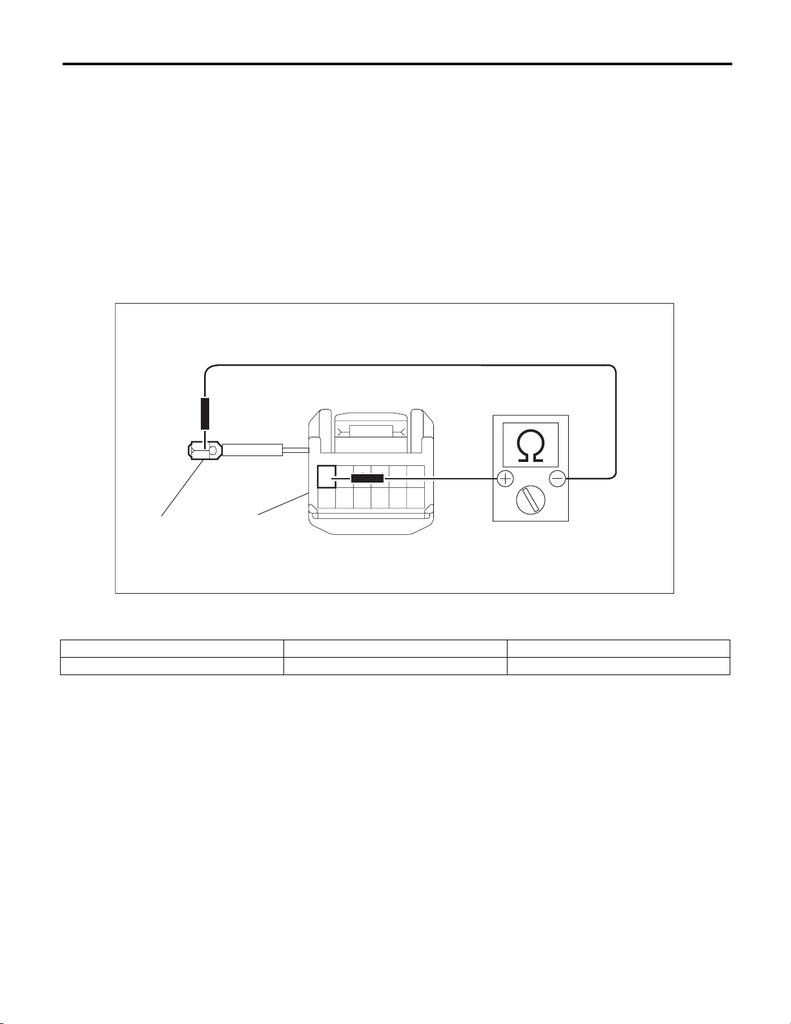

COM-10

Horn Switch

COMMUNICATION SYSTEM

5. Horn Switch

A: NOTE

Horn switch is a unit with the driver’s airbag module. For operation procedures, refer to “Driver’s Airbag Mod-

ule” in “AIRBAG SYSTEM”. <Ref. to AB-33, Driver’s Airbag Module.>

B: INSPECTION

1. CHECK HORN SWITCH

1) Remove the driver’s airbag module. <Ref. to AB-33, REMOVAL, Driver’s Airbag Module.>

2) Check that the horn switch connector is connected properly.

3) Measure the resistance between connectors.

Preparation tool:

Circuit tester

4) Replace the driver’s airbag module if the inspection result is not within the standard value.

(a) Ground terminal (b) Horn switch terminal

Terminal No. Inspection conditions Standard

Horn switch terminal — ground terminal Always Less than 1 Ω

COM00114

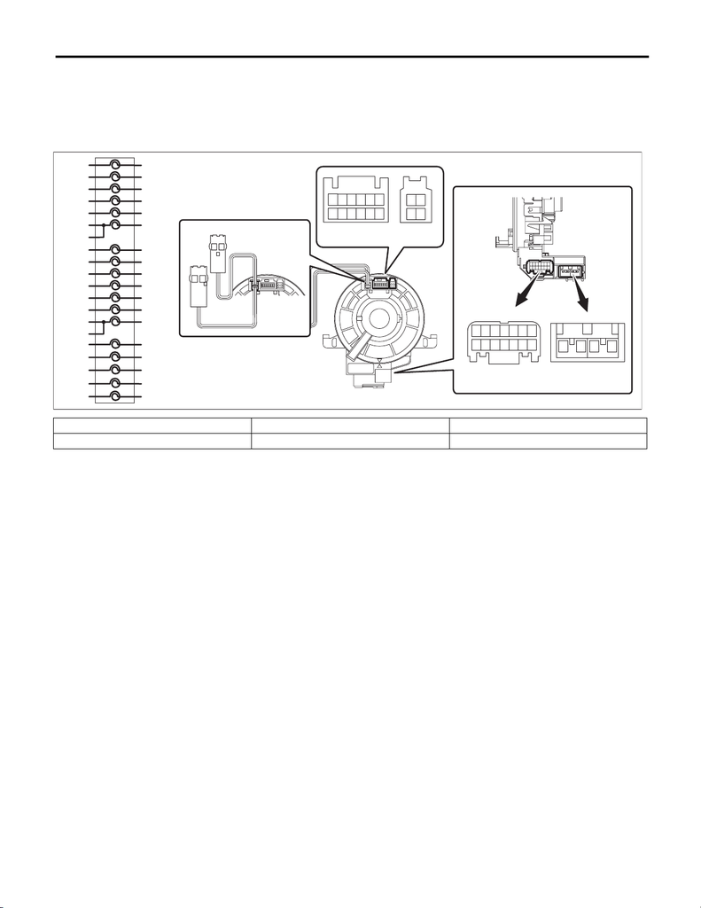

COM-11

Horn Switch

COMMUNICATION SYSTEM

2. CHECK ROLL CONNECTOR

1) Remove the roll connector. <Ref. to AB-60, REMOVAL, Roll Connector.>

2) Measure the resistance between connector terminals.

Preparation tool:

Circuit tester

3) Replace the roll connector if the inspection result is not within the standard value.

Terminal No. Inspection conditions Standard

A1 — C9 Always Less than 1 Ω

COM00123

[figure not shown]

COM-12

Horn Switch

COMMUNICATION SYSTEM

[figure not shown]

GLASS/WINDOWS/MIRRORS

GW

Page

1. General Description ...................................................................................2

2. Relay and Fuse ..........................................................................................7

3. Power Window System ..............................................................................9

4. Power Window Control Switch .................................................................11

5. Front Door Glass ......................................................................................19

6. Front Regulator and Motor Assembly ......................................................23

7. Remote Control Mirror System .................................................................25

8. Outer Mirror Assembly .............................................................................26

9. Remote Control Mirror Switch ..................................................................31

10. Rearview Mirror ........................................................................................33

11. Rear Door Glass ......................................................................................34

12. Rear Regulator and Motor Assembly .......................................................37

13. Windshield Glass .....................................................................................39

14. Rear Window Glass .................................................................................47

15. Rear Window Defogger System ...............................................................50

16. Wiper Deicer System ...............................................................................53